# Impact of Education Level on Satisfaction with Federal Government

Chen, Shupeng

2020-09-23

# Abstract

In capitalist countries, popular satisfaction with the federal government often determines whether it wins elections.In this paper we explore the 2019 CES dataset,which was a non-probability survey**<sup>1</sup>** conducted in the lead-up to the 2019 Federal Election. We found that people’’s education level is closely related to their satisfaction with the federal government.Our findings have certain reference value to the governing party’s re-election.

## Introduction

Education has been influencing human development and progress since ancient times. In today’s society, education has become particularly important for both individuals and countries. Scientific research has shown that higher education can not only improve the happiness index, but also reduce the crime rate in the society**<sup>2</sup>**.In this paper, through the study of 2019 CES data**<sup>3</sup>**, we find that education level affects people’s satisfaction with the federal government.The implications of this finding are not only for the general election but also for raising the importance of education.

## Data

The data was collected from 2019 Canadian Election Study with 620 variables. These variables include the respondent’s demographic characteristics, political status, economic level, educational background and other aspects**<sup>4</sup>**.In this paper, we will focus on **cps19_education** and **cps19_fed_gov_sat** theses two variables to determine the relationship between education level and government satisfaction. For the convenience of observation, we replaced the educational background of the respondents with figures.For example, 1 represents illiteracy, 2 primary school education, 3 junior high school education, 4 high school education but not complete, 5 high school education, and so on**<sup>5</sup>**.

As shown in graph 1 , More than 50 percent of respondents have a college degree or above, and nearly a quarter of respondents have a bachelor’s degree.In contrast to low education, less than 8 percent of respondents had less than a high school diploma.

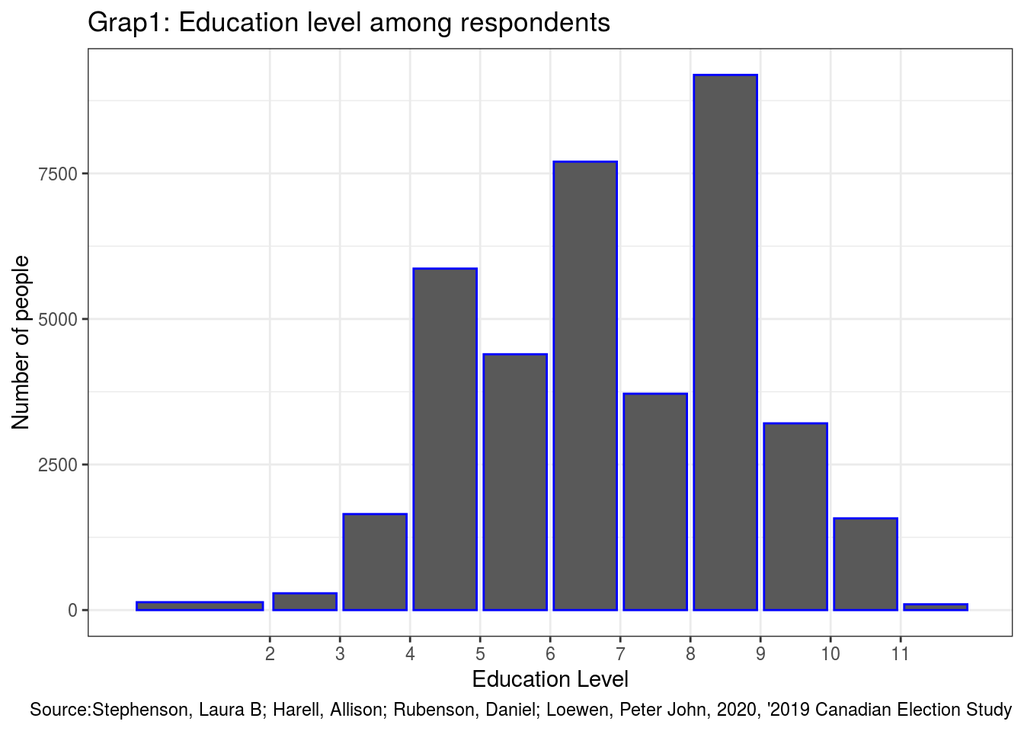

```r
ces2019_web%>%
  ggplot(aes(x=cps19_education))+geom_bar(colour="blue")+scale_x_binned(name="Education Level")+
  labs(y="Number of people",title="Grap1: Education level among respondents",caption= "Source:Stephenson, Laura B; Harell, Allison; Rubenson, Daniel; Loewen, Peter John, 2020, '2019 Canadian Election Study")+theme_bw()
```

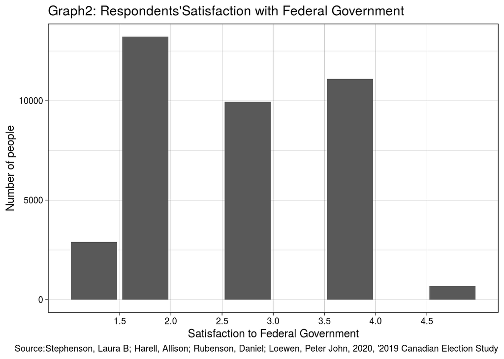

```r
ces2019_web%>%
  ggplot(aes(x=cps19_fed_gov_sat))+geom_histogram(stat="count")+scale_x_binned(name= "Satisfaction to Federal Government")+labs(y="Number of people",title="Graph2: Respondents'Satisfaction with Federal Government",caption= "Source:Stephenson, Laura B; Harell, Allison; Rubenson, Daniel; Loewen, Peter John, 2020, '2019 Canadian Election Study")+theme_linedraw()
```

## Result

[figure not shown]

```r
ces2019_web_1<-
  ces2019_web%>%
  filter(cps19_education<4)
ces2019_web_1<-
  ces2019_web_1%>%
  select(cps19_education,cps19_fed_gov_sat)
ces2019_web_1%>%
  ggplot(aes(x=cps19_education,y=cps19_fed_gov_sat))+geom_count()+labs(y="Satisfaction with Federal Government",x="Education Level",title="Graph3:Relationship between Satisfaction with Government and high Education",caption= "Source:Stephenson, Laura; Harell, Allison; Rubenson, Daniel; Loewen, Peter, 2020, '2019 CES")+theme_linedraw()
```

[figure not shown]

```r
ces2019_web_2<-
  ces2019_web%>%
  filter(cps19_education>=4)
ces2019_web_2<-
  ces2019_web_2%>%
  select(cps19_education,cps19_fed_gov_sat)
ces2019_web_2%>%
  ggplot(aes(x=cps19_education,y=cps19_fed_gov_sat))+geom_count(colour="blue")+labs(y="Satisfaction with Federal Government",x="Education Level",title="Graph4:Relationship between Satisfaction with Government and low Education",caption= "Source: Stephenson, Laura; Harell, Allison; Rubenson, Daniel; Loewen, Peter, 2020, '2019 CES")+theme_classic()
```

## Weakness and next steps

Although the data sources of this article are reliable, there are inevitably some problems with such a large amount of data.For example, respondents may respond less positively and accurately to many long survey questions.In addition, when considering the impact of education on government satisfaction, we do not consider many factors that can indirectly affect people’s satisfaction with government, such as the epidemic and the economic crisis.Moreover, in this paper, a large amount of data was removed when calling filter function which results in a less predictable model. Therefore, in order to improve this article, we can reduce the questions and length of the questionnaire so as to improve the accuracy of the data.And to predict the election as much as possible by taking into account more variables.Finally, I would like to say that this article should be used as a reference article for interested readers, not as a basis for predicting the general election.

## Appendix

-**<sup>1</sup>**non_probability survey : Non-probability survey is defined as survey technique in which the researcher selects samples based on the subjective judgment of the researcher rather than random selection

-**<sup>4</sup>** To find out more information about what variables had been collected , Paul A. Hodgetts and Rohan Alexander (2020).https://hodgettsp.github.io/cesR/

-**<sup>5</sup>** 1 represents illiteracy, 2 primary school education, 3 junior high school education, 4 high school education but not complete, 5 high school education,6 community college but not complete , 7 community college, 8 university education but not complete,9 bachelor’s degree, 10 master’s degree, 11 doctor’s degree 12 prefer not to say.

## Reference

- **<sup>2</sup>**Hjalmarsson, Randi; Lochner, Lance (2012) : The Impact of Education on Crime: International Evidence, CESifo DICE Report, ISSN 1613-6373, ifo Institut - LeibnizInstitut für Wirtschaftsforschung an der Universität München, München, Vol. 10, Iss. 2, pp
- **<sup>3</sup>**Stephenson, Laura B; Harell, Allison; Rubenson, Daniel; Loewen, Peter John, 2020, ‘2019 Canadian Election Study - Online Survey’, https://doi.org/10.7910/DVN/DUS88V, Harvard Dataverse, V1
- Stephenson, Laura, Allison Harrel, Daniel Rubenson and Peter Loewen. Forthcoming. ‘Measuring Preferences and Behaviour in the 2019 Canadian Election Study,’ Canadian Journal of Political Science.LINK: https://dataverse.harvard.edu/dataset.xhtml?persistentId=doi:10.7910/DVN/DUS88V
- Paul A. Hodgetts and Rohan Alexander (2020). cesR: Access the CES Datasets a Little Easier.. R package version 0.1.0.
- Hadley Wickham, Jim Hester and Winston Chang (2020). devtools: Tools to Make Developing R Packages Easier. R package version 2.3.2. https://CRAN.R-project.org/package=devtools
- Hadley Wickham and Jennifer Bryan (2020). usethis: Automate Package and Project Setup. R package version 1.6.3. https://CRAN.R-project.org/package=usethis
- Wickham et al., (2019). Welcome to the tidyverse. Journal of Open Source Software, 4(43), 1686, https://doi.org/10.21105/joss.01686
- R Core Team (2020). R: A language and environment for statistical computing. R Foundation for Statistical Computing, Vienna, Austria. URL https://www.R-project.org/.
- JJ Allaire, Jeffrey Horner, Yihui Xie, Vicent Marti and Natacha Porte (2019). markdown: Render Markdown with the C Library ‘Sundown’. R package version 1.1. https://CRAN.R-project.org/package=markdown